# Quast Reference Testing

Håkon Kaspersen

07.11.2018

```r
# Data import and wrangling
refs <- read.table("../data/ecoli_ref.tsv", sep = "\t", header = TRUE, stringsAsFactors = FALSE)

filenames <- file_names_recursive(path)

data_list <- lapply(filenames,
                      FUN = function(file) {
                        read.delim(paste0(path, "/", file),
                                   sep = "\t",
                                   header = TRUE,
                                   stringsAsFactors = FALSE)
                      })

data_list <- lapply(data_list, function(df) mutate_all(df, as.character))

names(data_list) <- filenames

df <- bind_rows(data_list, .id = "ref")

df2 <- create_df(df) %>%
  left_join(refs, by = "reference")
```

# 1 Information

## 1.1 Reference sequences

Below is a table over the references used in the various Quast analyses.

```r
refs
```

| reference | name | accession | size | plasmid |
| --- | --- | --- | --- | --- |
| ref1 | E. coli K12 | GCF_000005845.2 | 4641652 | None |
| ref2 | E. coli IAI39 | GCF_000026345.1 | 5132068 | None |
| ref3 | E. coli O104:H4 | GCF_000299455.1 | 5437407 | 3 |
| ref4 | E. coli O83:H1 | GCF_000183345.1 | 4894879 | 1 |
| ref5 | E. coli O157:H7 Sakai | GCA_000008865.2 | 5594605 | 2 |
| ref6 | E. coli O157:H7 Sakai Chrom | GCA_003028755.1 | 4709905 | None |

## 1.2 Sequencing methodology

```r
df2 %>%
  select(group, short_group) %>%
  group_by(short_group) %>%
  summarise_all(funs(func_paste))
```

| short_group | group |
| --- | --- |
| A | hiseq_flex_150bp |
| B | hiseqr_xt_250bp |
| C | hiseq_xt_125bp |

# 2 Plots

## 2.1 N50

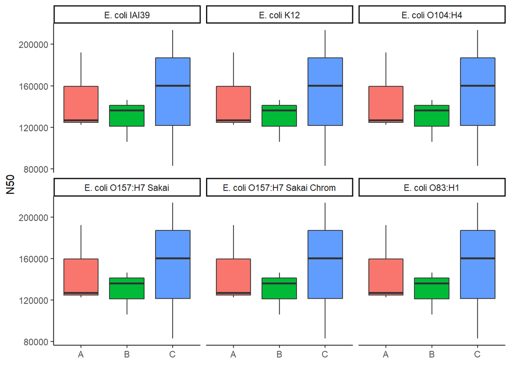

```r
# N50 per reference and sequencing group

ggplot(df2, aes(short_group, as.numeric(N50), fill = short_group))+
  geom_boxplot()+
  labs(y = "N50",
       x = NULL)+
  guides(fill = FALSE)+
  theme_classic()+
  facet_wrap(~name)
```

## 2.2 Number of contigs

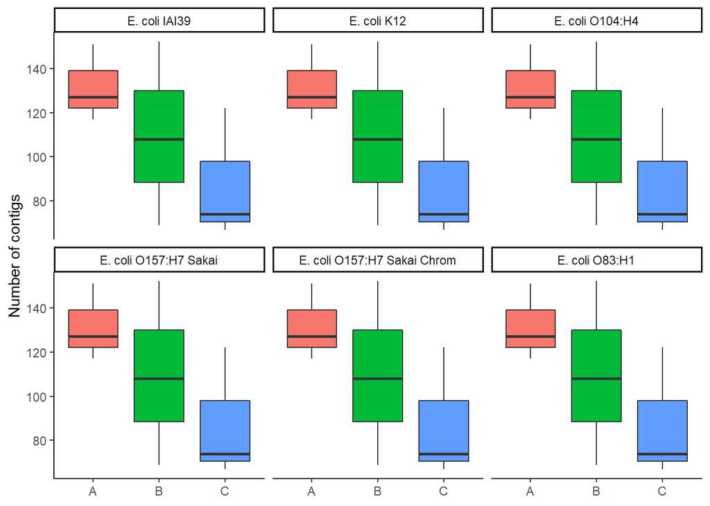

```r
# Number of contigs
ggplot(df2, aes(short_group, as.numeric(no_of_contigs), fill = short_group))+
  geom_boxplot()+
  labs(y = "Number of contigs",
       x = NULL)+
  guides(fill = FALSE)+
  theme_classic()+
  facet_wrap(~name)
```

## 2.3 Number of misassemblies

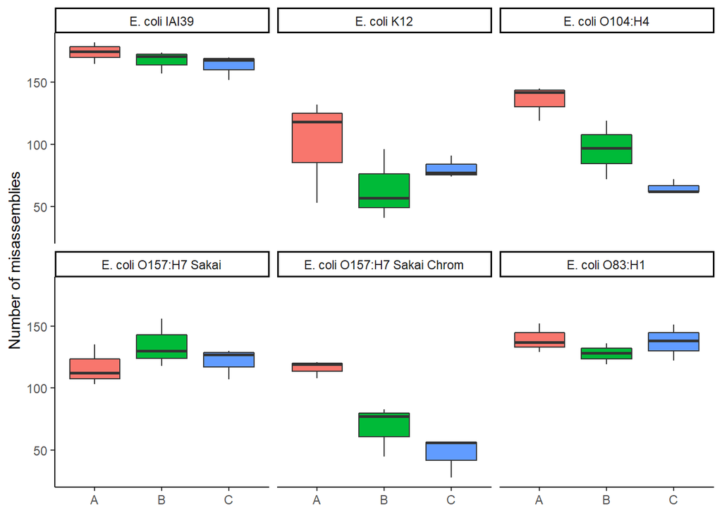

```r
# Number of misassemblies
ggplot(df2, aes(short_group, as.numeric(no_of_misassemblies), fill = short_group))+
  geom_boxplot()+
  labs(y = "Number of misassemblies",
       x = NULL)+
  guides(fill = FALSE)+
  theme_classic()+
  facet_wrap(~name)
```

## 2.4 Genome fraction

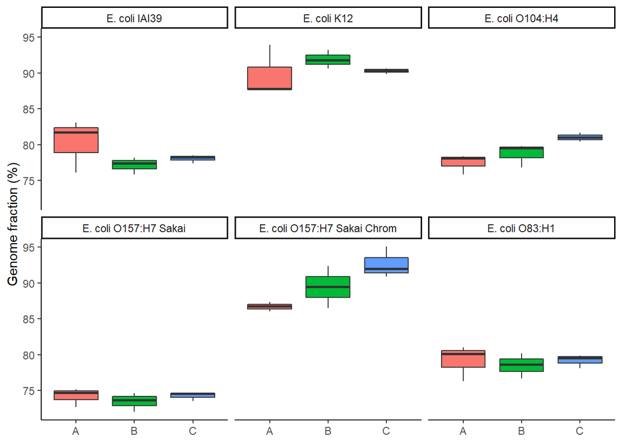

```r
ggplot(df2, aes(short_group, as.numeric(Genome.fraction....), fill = short_group))+
  geom_boxplot()+
  labs(y = "Genome fraction (%)",
       x = NULL)+
  guides(fill = FALSE)+
  theme_classic()+
  facet_wrap(~name)
```

## 2.5 N per 100kbp

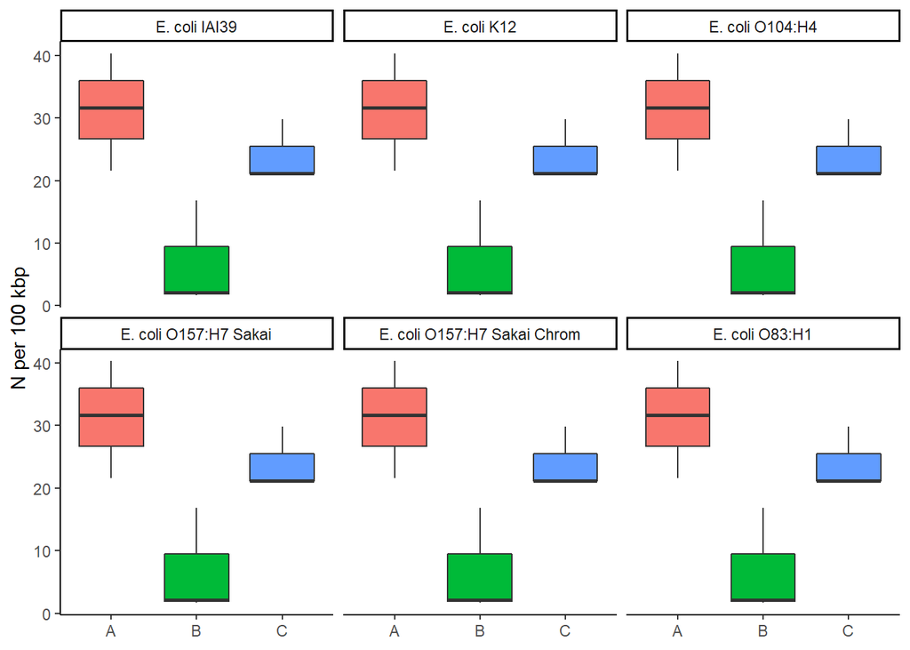

```r
ggplot(df2, aes(short_group, as.numeric(N_per_100kbp), fill = short_group))+
  geom_boxplot()+
  labs(y = "N per 100 kbp",
       x = NULL)+
  guides(fill = FALSE)+
  theme_classic()+
  facet_wrap(~name)
```

## 2.6 Largest contigs

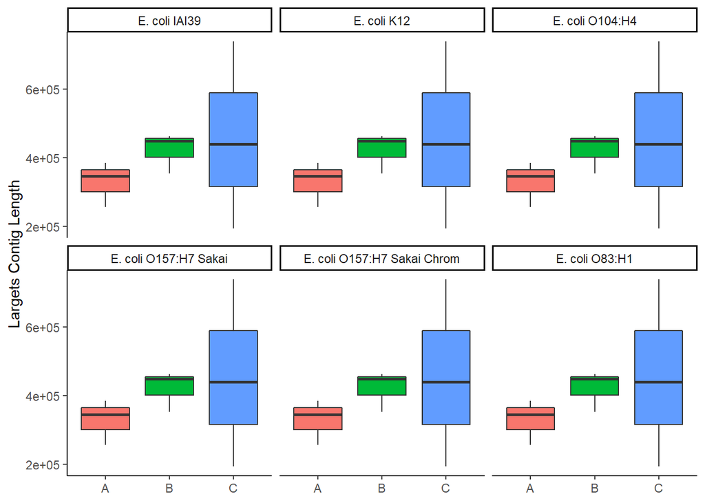

```r
ggplot(df2, aes(short_group, as.numeric(Largest.contig), fill = short_group))+
  geom_boxplot()+
  labs(y = "Largets Contig Length",
       x = NULL)+
  guides(fill = FALSE)+
  theme_classic()+
  facet_wrap(~name)
```